# STA305 Travaux Pratiques

Boris Hejblum

2018-2019

# Exercice 1 : Méthode de Monte-Carlo

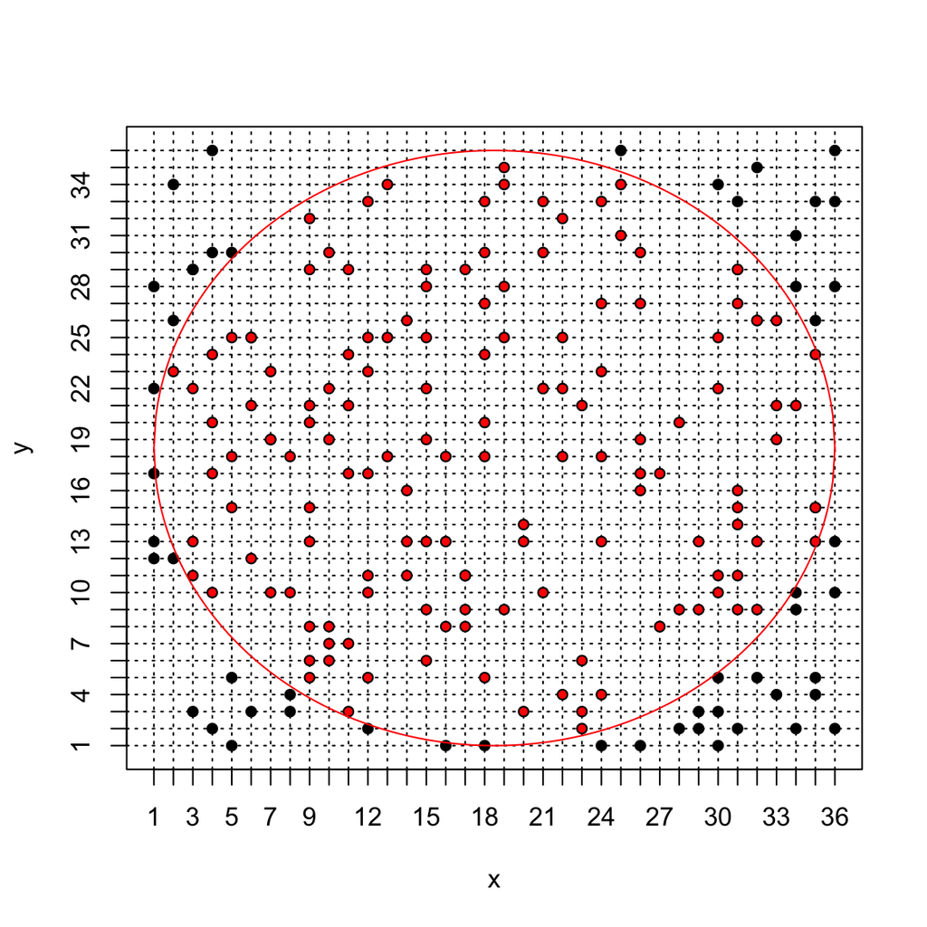

      ```r
      # Taille de la grille (résolution)
      ncases <- 36

      # Taille de l'échantillon de Monte Carlo
      npoints <- 200

      # Génération des points
      pp <- matrix(NA, ncol = 2, nrow = npoints)
      for (i in 1:nrow(pp)) {
          pp[i, ] <- roulette_coord(ncases)
      }

      # Dessin on commence par initialiser un plot vide, de la bonne taille avec
      # l'argument `type = n`
      plot(x = pp[, 1], y = pp[, 2], xlim = c(1, ncases), ylim = c(1, ncases), axes = 0,
          xlab = "x", ylab = "y", type = "n")
      ## on gradue les axes x puis y de 1 à 36
      axis(1, at = c(1:ncases))
      axis(2, at = c(1:ncases))
      ## on ajoute un carré encadrant le dessin
      box()
      ## on trace (en pointillés grâce à l'argument `lty = 3`) la grille sur
      ## laquelle sont échantillonnés nos points
      for (i in 1:ncases) {
          abline(h = i, lty = 3)
          abline(v = i, lty = 3)
      }
      ## on ajoute les points échantillonés
      lines(x = pp[, 1], y = pp[, 2], xlim = c(1, ncases), ylim = c(1, ncases), xlab = "x",
          ylab = "y", type = "p", pch = 16)
      ## on ajoute la représentation du cercle
      x.cercle <- seq(1, ncases, by = 0.1)
      y.cercle <- sqrt(((ncases - 1)/2)^2 - (x.cercle - (ncases + 1)/2)^2)
      lines(x.cercle, y = y.cercle + (ncases + 1)/2, col = "red")
      lines(x.cercle, y = -y.cercle + (ncases + 1)/2, col = "red")
      ## enfin on colori en rouge les points échantillonnés à l'intérieur du cercle
      in_circle <- apply(X = pp, MARGIN = 1, FUN = inside_circle, ncases = ncases)
      lines(x = pp[in_circle, 1], y = pp[in_circle, 2], xlim = c(0, ncases), ylim = c(0,
          ncases), xlab = "x", ylab = "y", type = "p", pch = 16, col = "red", cex = 0.7)
      ```

# Exercice 2 : Méthode d’échantillonage de la fonction inverse

Programmer un algorithme d’échantillonnage selon la loi Exponentielle de paramètre $\lambda$ grâce à la méthode de la fonction inverse et la fonction `R` `runif`. Comparer la densité de probabilité de l’échantillon obtenu avec cet algorithme par rapport à celle obtenue en utilisant la fonction `R` `rexp`.

# Exercice 3 : Algorithme de Metropolis-Hastings pour l’exemple historique (modèle Beta-Bernouilli)

En reprenant l’exemple historique, programmer un algorithme de Méetropolis-Hastings indépendant pour estimer la loi *a posteriori* du paramètre $\theta$ (la probabilité d’avoir une fille à la naissance). On prendra comme loi instrumentale la loi *a priori* de $\theta$, et on utilisera dans un premier temps un *a priori* uniforme. On considerera les $493\,472$ naissances observées à Paris entre 1745 et 1770, dont $241\,945$ furent des filles.

1. Programmer une fonction calculant le numérateur du posterior, dont on rappel l’expression : $p(\theta|n,S)\propto\theta^S(1-\theta)^{n-S}$ où $S = 241\,945$ et $n = 493\,472$.
2. Programmer l’algorithme de Metropolis-Hastings correspondant qui renvoie un vecteur de taille $n$ échantillonner selon la loi *a posteriori*. On prendra soin également de renvoyer le vecteur des probabilités d’acceptation.
3. Comparer la densité a posteriori obtenu avec l’algorithme M-H sur 2000 itérations à celle théorique. On prendra soin d’enlever les 500 premières itérations afin d’obtenir la convergence de la chaîne de Markov. Commenter ces résultats, notamment au vu des différentes probabilités d’acceptation calculées au cours de l’algorithme et des différentes valeurs échantillonnée pour $\theta$.
4. Considérer maintenant que l’on n’observe que $100$ naissances dont $49$ filles, et prendre un *a priori* de loi $\text{Beta}(\alpha = 3, \beta=3)$. Programmer l’algorithme correspondant et étudier à nouveau les résultats ainsi obtenus (on pourra faire $10\,000$ du nouvel algorithme de M-H).
5. **BONUS :** En utilisant les données de l’example historique et avec un *a priori* de loi $\text{Beta}(\alpha = 3, \beta=3)$, programmer un algorithme de Metropolis-Hastings à marche aléatoire (on pourra prendre un pas aléatoire gaussien d’écart-type $0,02$). Étudier à nouveau les résultats ainsi obtenus.

# Exercice 4 : Prise en main de `BUGS` & `JAGS`

Le [projet BUGS](https://www.mrc-bsu.cam.ac.uk/software/bugs/) (*Bayesian inference Using Gibbs Sampling*) a été initié en 1989 par l’unité de Biostatistique du MRC (*Medical Research Council*) de l’Université de Cambridge (au Royaume-Uni) afin de proposer un logiciel flexible pour l’analyse bayésienne de modèles statistique complexe à l’aide d’algrithme MCMC. Son implémentation la plus connue est `WinBUGS`, un logiciel clic-bouton disponible sous le système d’exploitation *Windows*. `OpenBUGS` est une implémentation focntionnant sous *Windows*, *Mac OS* ou *Linux*. [`JAGS`](http://mcmc-jags.sourceforge.net/) (*Just another Gibbs Sampler*) est une autre implémentation plus récente qui s’appuie également sur le langage `BUGS`. Enfin, il faut également noter le logiciel [`STAN`](http://mc-stan.org/), récemment développé à l’Université de Columbia qui n’est similaire à `BUGS` que dans son interface, s’appuyant sur des algorithmes MCMC innovants, comme par exemple les approches de Monte-Carlo Hamiltonien ou l’approche variationnelle. Une ressource très utile est le [manuel de l’utilisateur de JAGS](http://sourceforge.net/projects/mcmc-jags/files/Manuals/3.x/jags_user_manual.pdf).

Afin de se familiariser avec le logiciel `JAGS` (et son interface depuis `R` via le package `rjags`), nous nous intéressons ici à l’estimation a posteriori de la moyenne et de la variance d’un échantillon que l’on va modéliser avec une loi normale.

0. Charger le packages `rjags`.

Un model en `BUGS` a 3 composants :

- *le modèle* : spécifié dans un fichier externe (`.txt`) selon la syntaxe propre à `BUGS`
- *les données* : une liste contenant chaques données sous un nom correspondant à celui utilisé dans le modèle
- *les valeurs initiales* : (optionel) une liste contenant les valeurs initiales pour les différents paramètres à estimer
1. Génerer $N=50$ observations selon une loi normale de moyenne $m=2$ et d’écart-type $s=3$.
2. Lire l’aide du package `rjags`, puis enregistrer dans un fichier `.txt` le modèle en `BUGS` défini à l’aide du code suivant :

   ```
   # Modèle
   model{

     # Vraisemblance
     for (i in 1:N){
       obs[i]~dnorm(mu,tau)
     }

     # A priori
     mu~dnorm(0,0.0001) # propre mais très plat (faiblement informatif)
     tau~dgamma(0.0001,0.0001) # propre mais très plat (faiblement informatif)

     # Variables d'interet
     sigma <- pow(tau, -0.5)
   }
   ```

# Exercice 5 : Régression Bayésienne

Dans cet exercie, on va s’intéresser à l’essai thérapeutique ALBI-ANRS 070, qui visait à comparer l’efficacité et la tolérance de 3 stratégies antirétrovirales chez des patients infecté par le VIH-1 et naïf de tout traitement antirétroviral (Molina et al. 1999).

1. Charger les données à partir du cichier `donnees_albi.txt`.

On observe les variables suivantes : - `CD4` : le taux de lymphocytes T CD4+ (en cellules/mm<sup>3</sup>) - `CD4t` : la racine 4<sup>ème</sup> du taux de lymphocytes T CD4+ (`CD4t` = `CD4`<sup>1/4</sup>) - `LCV_50` : la charge virale plasmatique - `T` : le délai entre la visite et l’inclusion en jours divisé par 100 - `VIS` : le numéro de la visite - `TD` : le délai entre la visite et l’inclusion en semaines - `NUM_PAT` : l’indentifiant patient - `RAN_GRP` : l groupe de traitement $1$ (*d4t* + *ddI*), $2$ (alternance) ou $3$ (*AZT* + *3TC*))

2. Dans un premier temps, on souhaite expliquer le taux de CD4 en fonction de la charge virale.
   1. Représenter les `CD4t` en fonction de `LCV50` sous forme de *spaghetti plot* - retirer les observations problématiques.
   2. Écrire le modèle sous forme mathématique.
   3. Écrire le modèle en `BUGS` et le sauvegarder dans un fichier `.txt`
   4. Créer l’objet `jags`correspondant dans `R` et obtenir un échantillon de taille 1000 pour les 3 paramètres d’intérêt
   5. Avant d’interpréter les résultats, effectuer les diagnostiques de convergences. Que remarque-t-on ?
   6. À l’aide de la fonction `window` retirer les 500 premières itérations du résultat. À quoi cela sert-il ? Cela suffit-il à résoudre les problèmes de convergence ?
   7. À l’aide du paramètre `thin` dans la fonction `coda.samples`, faire diminuer l’autocorrelation tout en conservant une taille d’échantillon de Monte-Carlo acceptable. S’intéresser à la taille d’échantillon effective l’aide de la fonction `effectiveSize`.
3. Comparer ces résultats à ceux obtenus par une approche fréquentistes
4. Ajouter un intercept aléatoire par patients dans le modèle
5. À l’aide de la fonction `dic.samples` calculer le $DIC$ pour chacun des deux modèles (avec ou sans intercept aléatoires). Quel est le meilleur modèle au sens de ce critère (plus il est bas, meilleur est le modèle)?
6. **BONUS :** Ajouter une pente aléatoire. Comparer ce modèle avec celui retenu à la question précédente.

# Exercice 6 : Bootstrap pour le *t*-test (alias: Monte-Carlo, le retour)

On veut comparer deux moyennes.

0. Générer 2 échantillons chacun de taille $n=15$, de même variance $s^2 = 9$ et de moyenne respective $10$ et $8$. On les notera échantillons `a` et `b`.
1. Comparaison du t-test asymptotique, Monte-Carlo, Bootstrap
   1. Rappeler les hypothèses du *t*-test de Student, et effectuer un test unilatérale de l’hypothèse alternative unilatérale $H_1 : \mu_a >\mu_b$ au niveau de risque de l’erreur de type I $\alpha=5%$
   2. Calculer la borne inférieure de l’intervalle de confiance **bootstrap** de la différence de moyenne à partir de $20\;000$ échantillons *bootstrap*. Calculer également la p-valeur associée au test unilatéral. Enfin, représenter la distribution des différences bootstrap, et faire figurer la valeur observée.
   3. Grâce au bootstrap, estimer l’écart-type de la différence de moyenne. La comparer à la formule asymptotique ($\sqrt{\frac{Var(a)}{n} + \frac{Var(b)}{n}}$). Commenter.
   4. Recommencer avec $n=200$ et commenter à nouveau.
   5. Utiliser la méthode de Monte-Carlo. Comparer aux résultats précédents et commenter.
2. À l’aide de la méthode de Monte-Carlo verifier que le *t*-test de Student contrôle bien l’erreur de type I au niveau $\alpha = 5%$ voulu lorsque $n=15$?
3. À l’aide de la méthode de Monte-Carlo , représenter la puissance du test pour différentes valeur de $n$ ?
4. **BONUS :** utiliser un test par permutation et comparer aux résultats précédents

# Bibliographie

Molina, Jean-Michel, Geneviève Chêne, Françoise Ferchal, Valérie Journot, Isabelle Pellegrin, Marie-Noëlle Sombardier, Corinne Rancinan, et al. 1999. “The Albi Trial: A Randomized Controlled Trial Comparing Stavudine Plus Didanosine with Zidovudine Plus Lamivudine and a Regimen Alternating Both Combinations in Previously Untreated Patients Infected with Human Immunodeficiency Virus.” *The Journal of Infectious Diseases* 180 (2): 351–58.